# red_wine

karthik

December 25, 2015

# Overview of red wind data set

### Dimention of red wind data set

```
## [1] 1599   13
```

## Various variable involed in the data set

```
##  [1] "X"                    "fixed.acidity"        "volatile.acidity"
##  [4] "citric.acid"          "residual.sugar"       "chlorides"
##  [7] "free.sulfur.dioxide"  "total.sulfur.dioxide" "density"
## [10] "pH"                   "sulphates"            "alcohol"
## [13] "quality"
```

## Data Structure

```
## 'data.frame':    1599 obs. of  13 variables:
##  $ X                   : int  1 2 3 4 5 6 7 8 9 10 ...
##  $ fixed.acidity       : num  7.4 7.8 7.8 11.2 7.4 7.4 7.9 7.3 7.8 7.5 ...
##  $ volatile.acidity    : num  0.7 0.88 0.76 0.28 0.7 0.66 0.6 0.65 0.58 0.5 ...
##  $ citric.acid         : num  0 0 0.04 0.56 0 0 0.06 0 0.02 0.36 ...
##  $ residual.sugar      : num  1.9 2.6 2.3 1.9 1.9 1.8 1.6 1.2 2 6.1 ...
##  $ chlorides           : num  0.076 0.098 0.092 0.075 0.076 0.075 0.069 0.065 0.073 0.071 ...
##  $ free.sulfur.dioxide : num  11 25 15 17 11 13 15 15 9 17 ...
##  $ total.sulfur.dioxide: num  34 67 54 60 34 40 59 21 18 102 ...
##  $ density             : num  0.998 0.997 0.997 0.998 0.998 ...
##  $ pH                  : num  3.51 3.2 3.26 3.16 3.51 3.51 3.3 3.39 3.36 3.35 ...
##  $ sulphates           : num  0.56 0.68 0.65 0.58 0.56 0.56 0.46 0.47 0.57 0.8 ...
##  $ alcohol             : num  9.4 9.8 9.8 9.8 9.4 9.4 9.4 10 9.5 10.5 ...
##  $ quality             : int  5 5 5 6 5 5 5 7 7 5 ...
```

## Dependent Variable’s (qualtiy) statistics Summary

```
##
##   3   4   5   6   7   8
##  10  53 681 638 199  18
```

```
##    Min. 1st Qu.  Median    Mean 3rd Qu.    Max.
##   3.000   5.000   6.000   5.636   6.000   8.000
```

## Histogram for Quality of Wine

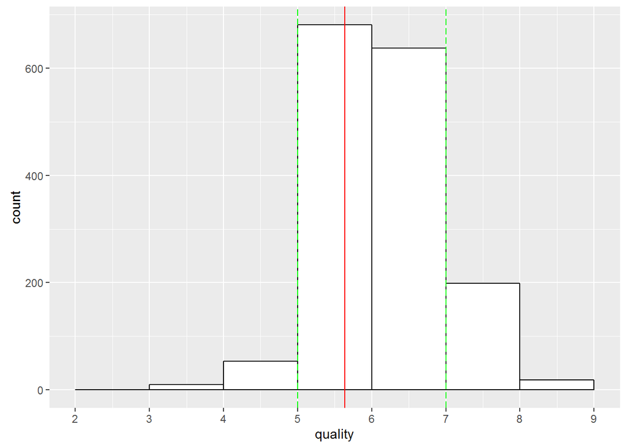

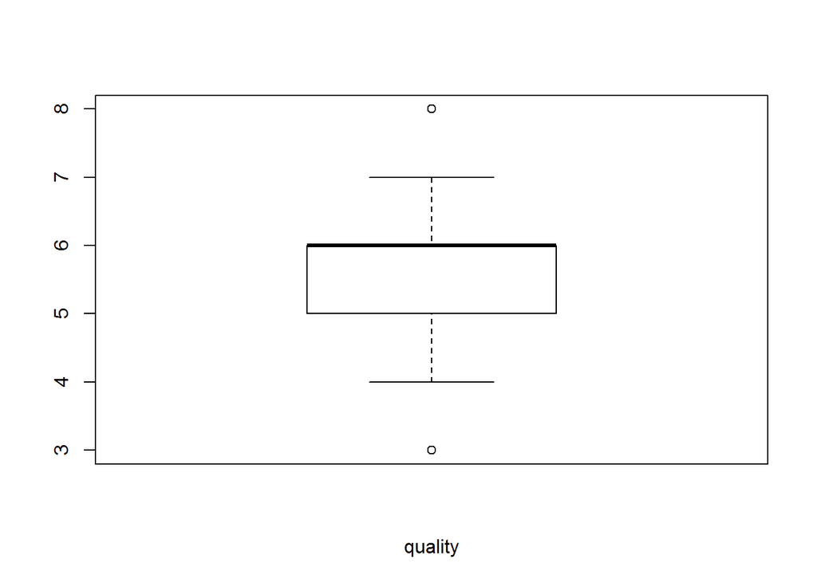

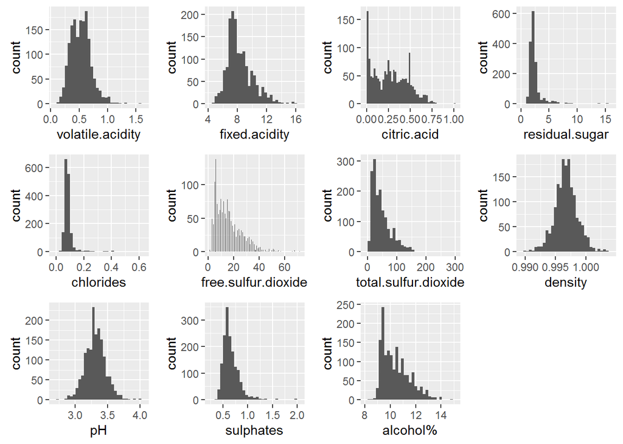

# Initial Findings from Histogram

#### volatile acidity

- Most of the wine has a volatile acidity concentration between $0.4 g/dm^{3}$ and $0.53 g/dm^{3}$. More over the data is normaly distributed.

#### fixed acidity

- Most of the wine has fixed acidity concentration between $7 g/dm^{3}$ and $9 g/dm^{3}$.
- There are some outlies which are spread out to $16 g/dm^{3}$.

#### citric.acid

- There are alot of ${0}$ which means a lot of wine don’t has citric acid. It also make sense too because citric acid is added as a freshner or flavor to wines not as a key ingredients in cooking wine.
- I deffinitly like to investigate more on this lated as adding flavo make any changes to the quality of the wine.

#### residual sugar

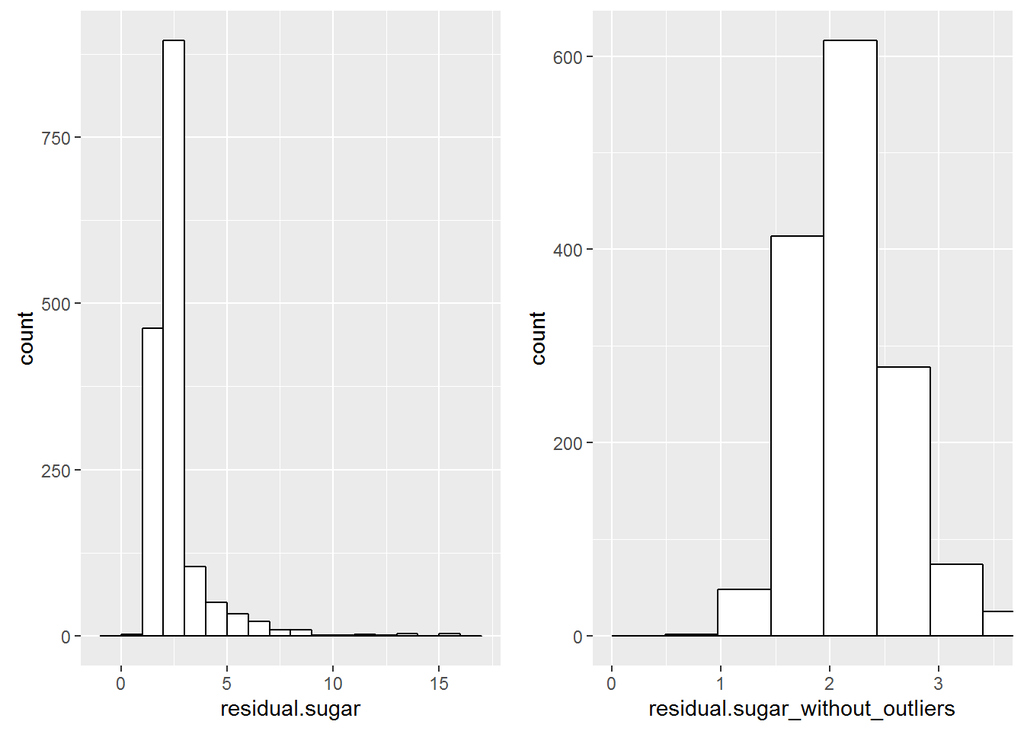

#### chlorides:

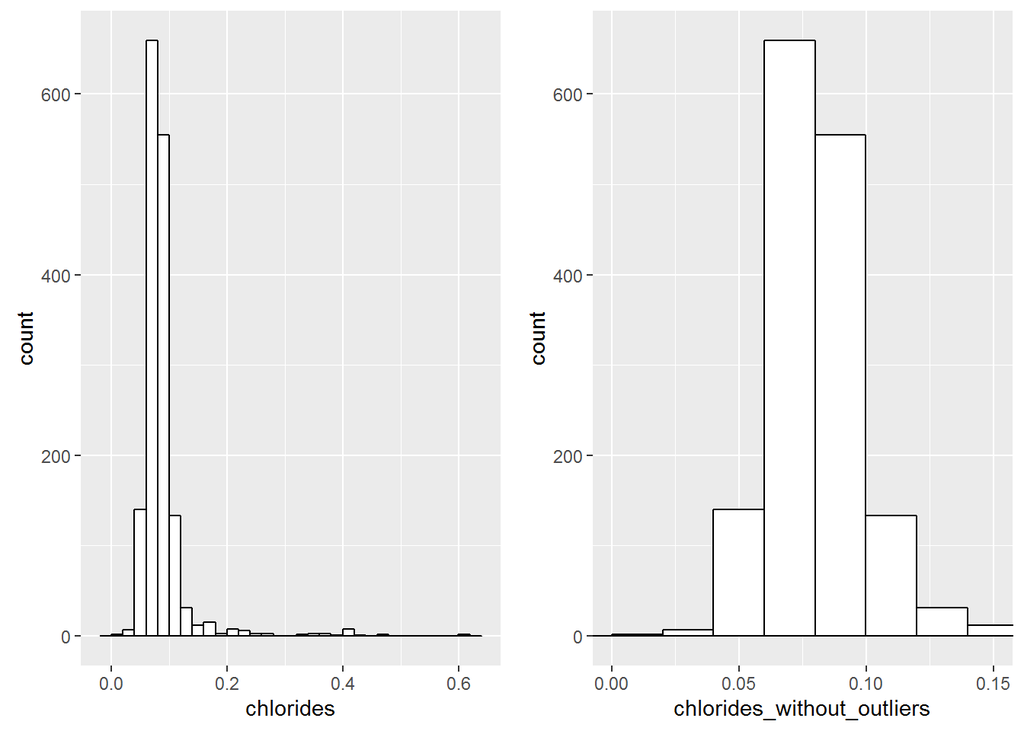

- Chloride is a salt. I don’t like my wine to tase salty and others too i  
  guess that is why the amount of salt contain is less. Almost 75% of sample  
  have less then $0.09 g/dm^{3}$.
- once the outliers are removed it very clear that the chloride are spread very well normaly spread across simple.

#### density

- Depending on the percent alcohol and sugar content the density of wine is close to water i will investigate how density of the wine affects the quality.
- One question does quality increses as the density of the wine moves close towords the density of the water?.

#### pH

- pH is the sacle is used to measure liquid is acid or base most of wine are have scale feom ${3}-{4}$ so as our sample.
- The question is there trend in the quality of wine as the pH level increase or deceases?.

#### Alcohol

- Alcohol is one of the importain ingredients thats why all wine bottles carry lable with percentage of alcohol contant but how much alcohol contain does a good quality wine has? let me do more anlaysis.

### Transforming variable to check normality.

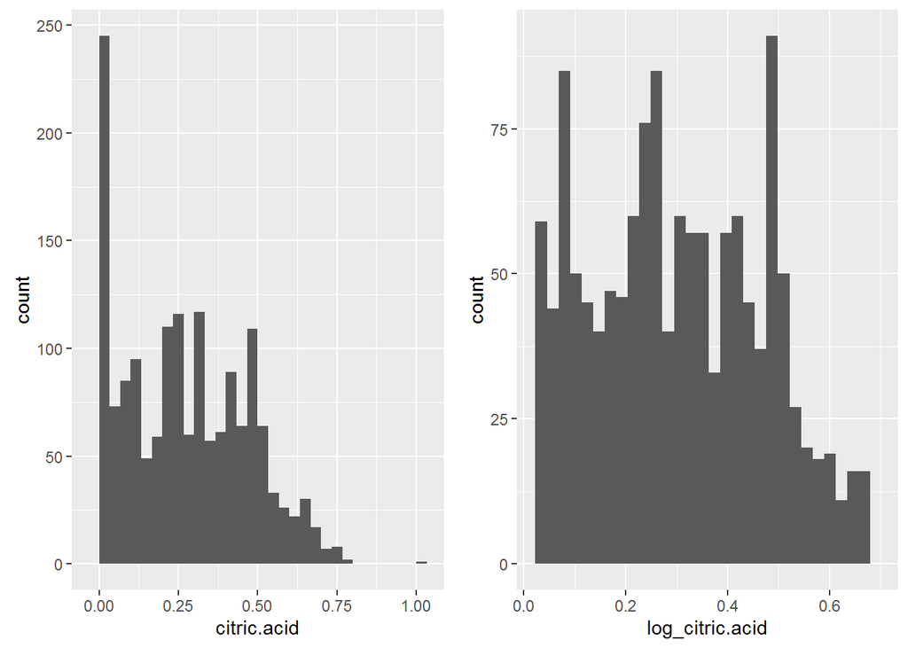

> - dose wine sample has a lot of citric acid with ${0}$ value ?*

*Yes, the number of `citric.acid` with 0 value is ${132}$. So its not that data is missing but acutually the alot of wine doesn’t have `citric.acid`.let me remove the 0 and do log transformation so that i can find any distribution from the histogram.* even after the transfomation there isn’t any distibution visiable. i will investiage more with a box plot to check for trend.

## Corealtion between Variables and Quality

| Positive correation | Negative correation |
| --- | --- |
| alcohol =${0.476}$ | volatile acidity = ${-0.390}$ |
| sulphates=${0.251}$ | total sulpure di oxide = ${-0.185}$ |
| citric acid=${0.226}$ | density = ${-0.174}$ |
| fixed acidity=${0.124}$ | chlorides = ${-0.057}$ |
| residual sugar=${0.013}$ | pH = ${-0.057}$ |
| ${---}$ | free sulfur dioxide = ${-0.050}$ |

# Bivariant Plot and Analysis

## Boxpot of differnt Variable with Quality

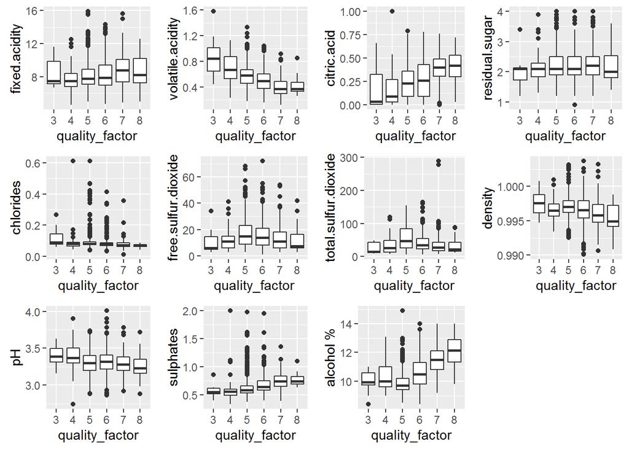

- If we follow the tread of the median bar in the box plot the we can find if any tread between the quality and the other variable.
- The variable `alcohol` ,`sulphates` , `citric.acid` all have a positive trend.
- The variable `volatile` has negative trend.
- All other variables doesn’t have a good variation to have clear picture of there tread.

#### Investigate more on Alcohol ,Sulphates , Citric.acid, Volatile

To have more clear understanding of quality variable the quality is splited into 3 categories **bad** (score [0-4]), **good** (score [5-6]), **best** (score[7-8])

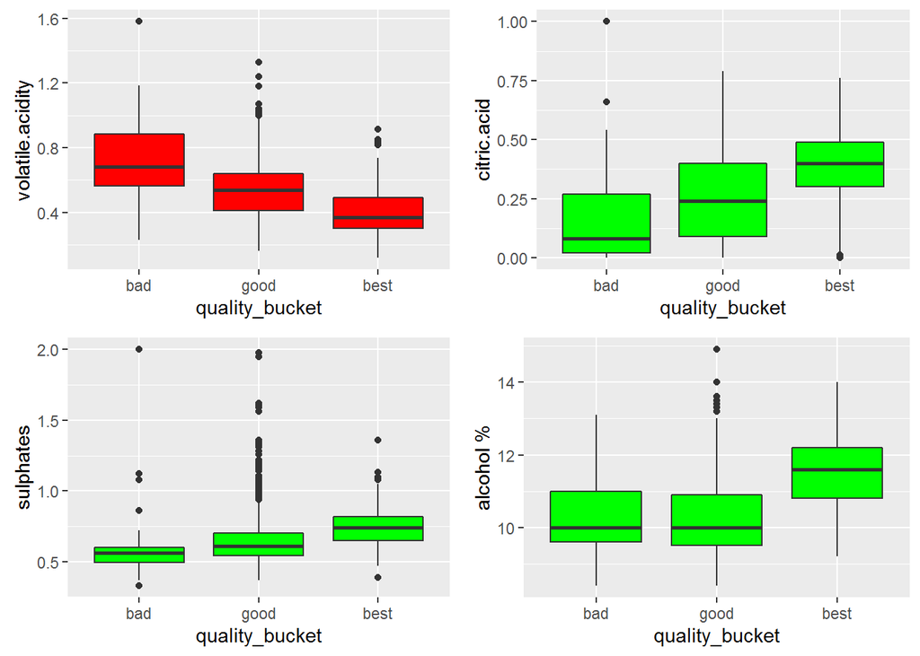

The trends are more clear and very well labeled for good visualisation. The **red color** of `volatile.acidity` shows it has negative trend while the **green color** of `citric.acid`, `sulphates`, `alcohol` shows the positive trend with *wine quality*

The volatile acid, sulphate, alchol, and citric acid have high correlation to wine quality. I like to check how these variable are corelated to each other with polted with a scatter plot.

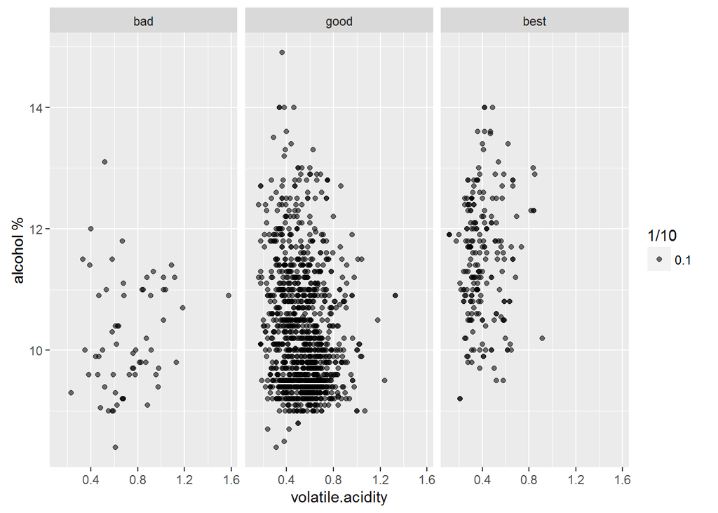

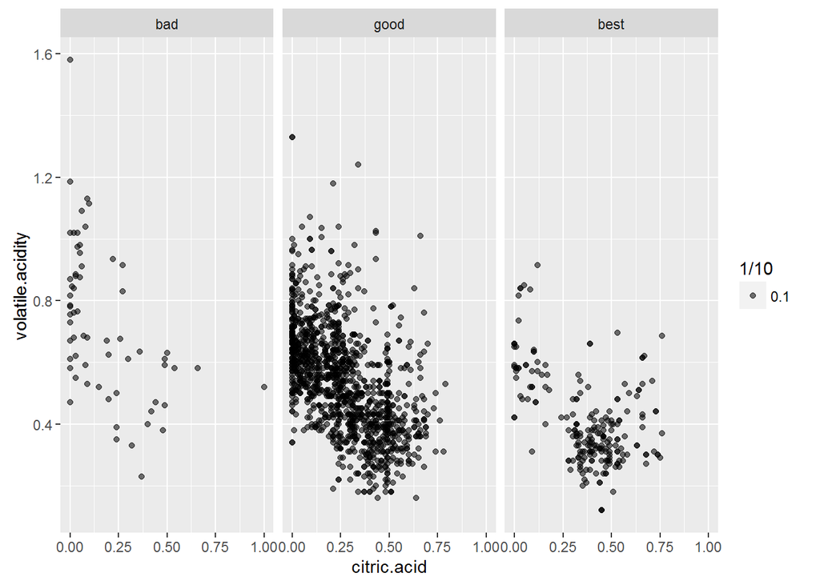

[figure not shown]

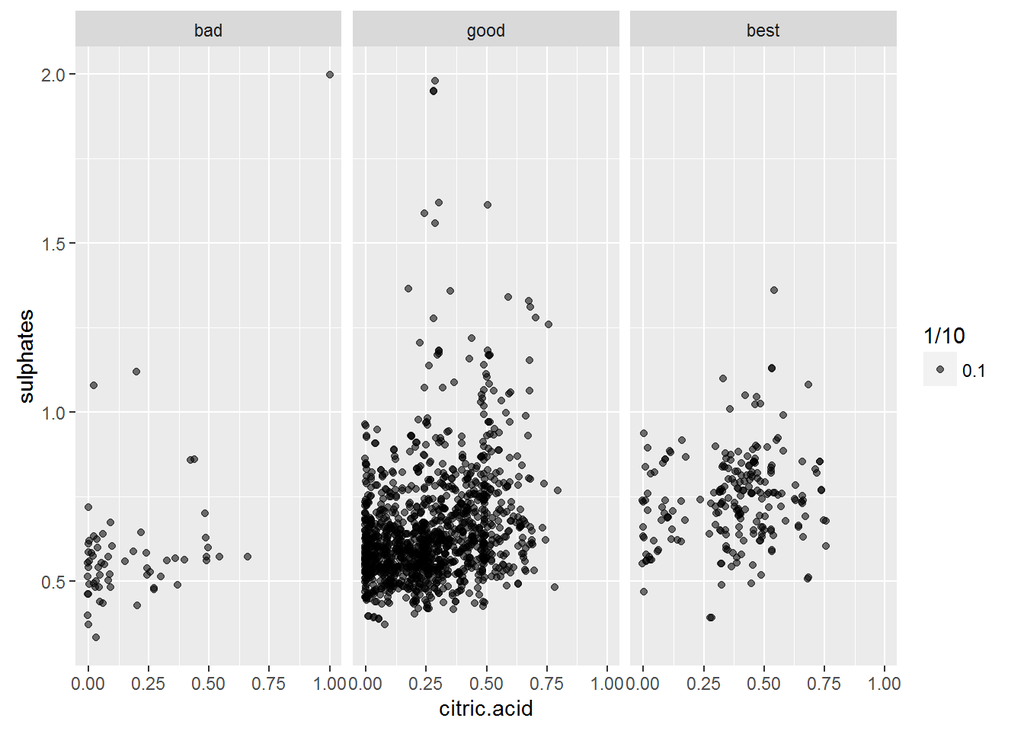

```
##
## Calls:
## m1: lm(formula = I(quality) ~ I(alcohol), data = wine)
## m2: lm(formula = I(quality) ~ I(alcohol) + citric.acid, data = wine)
## m3: lm(formula = I(quality) ~ I(alcohol) + citric.acid + sulphates,
##     data = wine)
## m4: lm(formula = I(quality) ~ I(alcohol) + citric.acid + sulphates +
##     volatile.acidity, data = wine)
## m5: lm(formula = I(quality) ~ I(alcohol) + citric.acid + sulphates +
##     volatile.acidity + fixed.acidity + residual.sugar + chlorides +
##     total.sulfur.dioxide + density + pH, data = wine)
##
## ============================================================================
##                           m1         m2         m3         m4         m5
## ----------------------------------------------------------------------------
## (Intercept)            1.875***   1.830***   1.434***   2.646***   25.493
##                       (0.175)    (0.171)    (0.176)    (0.201)    (21.142)
## I(alcohol)             0.361***   0.346***   0.338***   0.309***    0.275***
##                       (0.017)    (0.016)    (0.016)    (0.016)     (0.026)
## citric.acid                       0.730***   0.513***  -0.079      -0.231
##                                  (0.090)    (0.093)    (0.104)     (0.145)
## sulphates                                    0.814***   0.696***    0.929***
##                                             (0.107)    (0.103)     (0.114)
## volatile.acidity                                       -1.265***   -1.124***
##                                                        (0.113)     (0.120)
## fixed.acidity                                                       0.031
##                                                                    (0.026)
## residual.sugar                                                      0.020
##                                                                    (0.015)
## chlorides                                                          -1.825***
##                                                                    (0.419)
## total.sulfur.dioxide                                               -0.002***
##                                                                    (0.001)
## density                                                           -21.594
##                                                                   (21.575)
## pH                                                                 -0.361
##                                                                    (0.190)
## ----------------------------------------------------------------------------
## R-squared                 0.227      0.257      0.284      0.336      0.359
## adj. R-squared            0.226      0.256      0.282      0.334      0.355
## sigma                     0.710      0.696      0.684      0.659      0.649
## F                       468.267    276.595    210.501    201.777     88.909
## p                         0.000      0.000      0.000      0.000      0.000
## Log-likelihood        -1721.057  -1688.711  -1659.955  -1599.093  -1571.168
## Deviance                805.870    773.917    746.576    691.852    668.105
## AIC                    3448.114   3385.421   3329.910   3210.186   3166.337
## BIC                    3464.245   3406.930   3356.795   3242.448   3230.862
## N                      1599       1599       1599       1599       1599
## ============================================================================
```

- Even after adding all the variable i couldn’t find a good fix. There are 2 solution to this problem.
- Add two are more variable to get a new variable and add it to the model. I’m definitly skeptical in doing so since the full model $R-squared={.359}$ which is a just a 2% high when compaired with a model have `alcohol`, `citric.acid`, `sulphates`, `volatile.acidity`.
- An other solution is to use a non-leaner model or do somthing call train and test your model to have a good prediction and of course a good quality wine.

## Multi-Varient Plot:

The variable such as `pH`, `density` may not directly corelated with the wine quality but they are a good measure of properties of wine. i will investigate more on them in coming analysis.

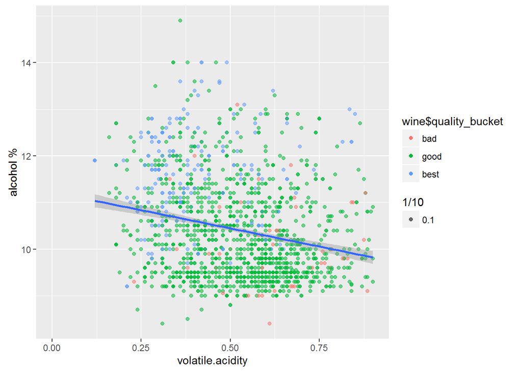

The scatter plot deffinitly separate the `best` Vs `good` wine. The best wine are the one with high alcohol with low volatile contain.

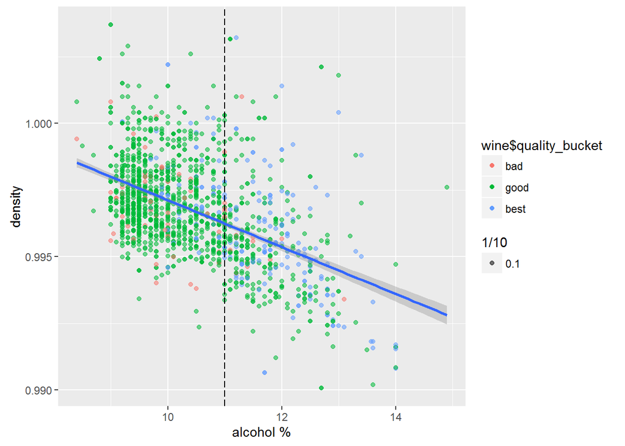

There is a trend that most of the best quality wine are from the graph it is clear that the wine with more alcohol contant and less density falls in the `best` quality and the `good` quality wine has comparetively less alcohol contain and dinsity to best quality.

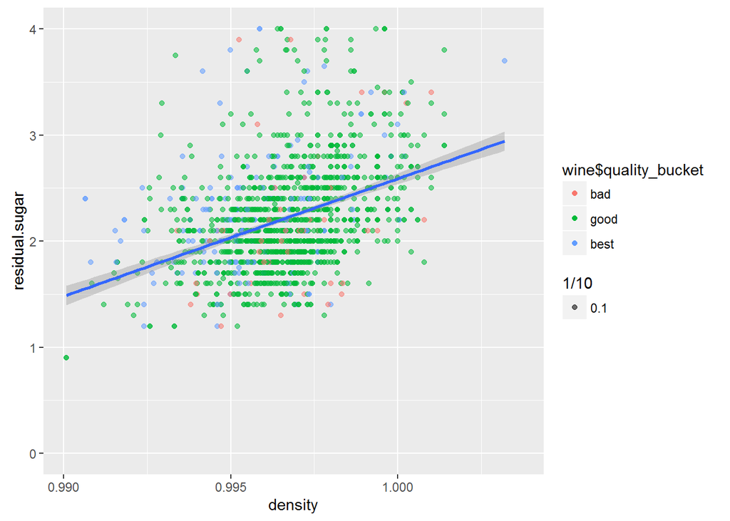

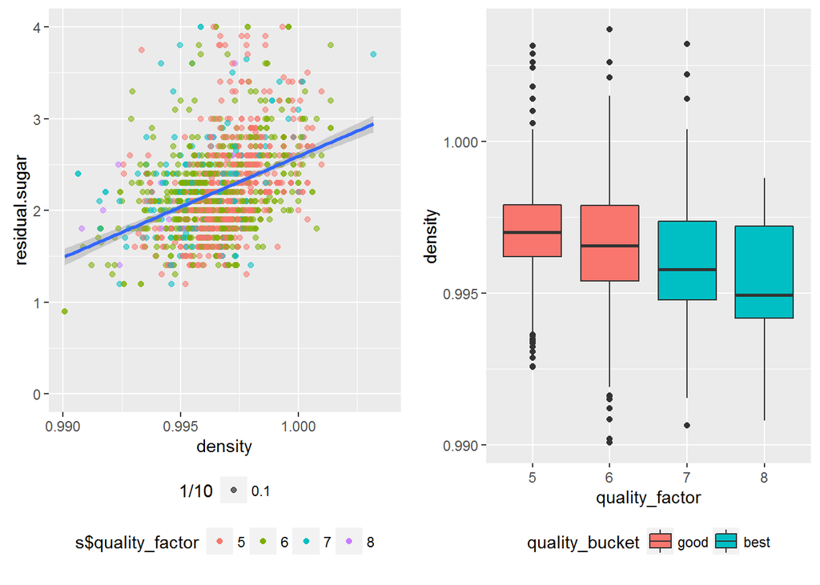

From the scatter plot there is deffinatly a trend as the density increases the residual sugar level increases this led to a simple question.

> - Is a good quality wine has more density or lesser density? *

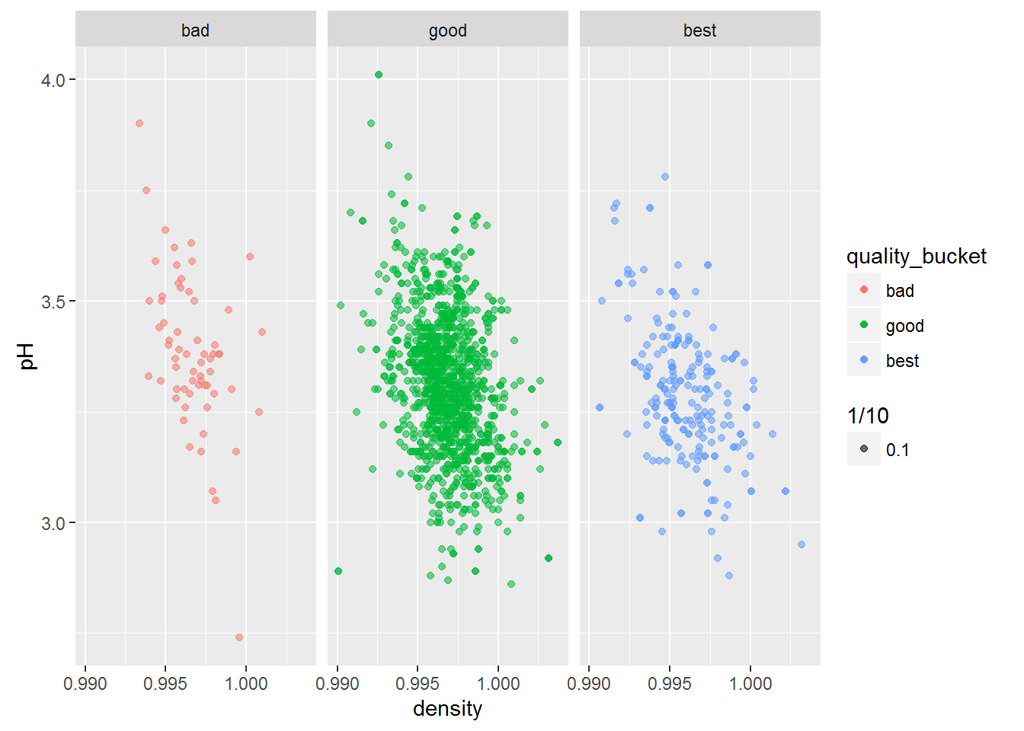

I though there might be some relationship between the density and pH but it seem there are not much to infer between them.

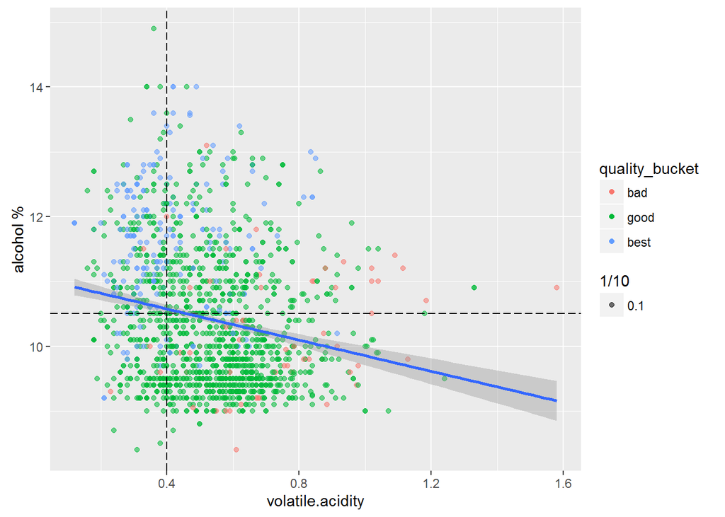

The scatter plot shows most of the best quality of the wine follow on high alcohol contain and low volatile acidity.

# Final Plots

## Plot One [box plot for *quality* vs *alcohol*]

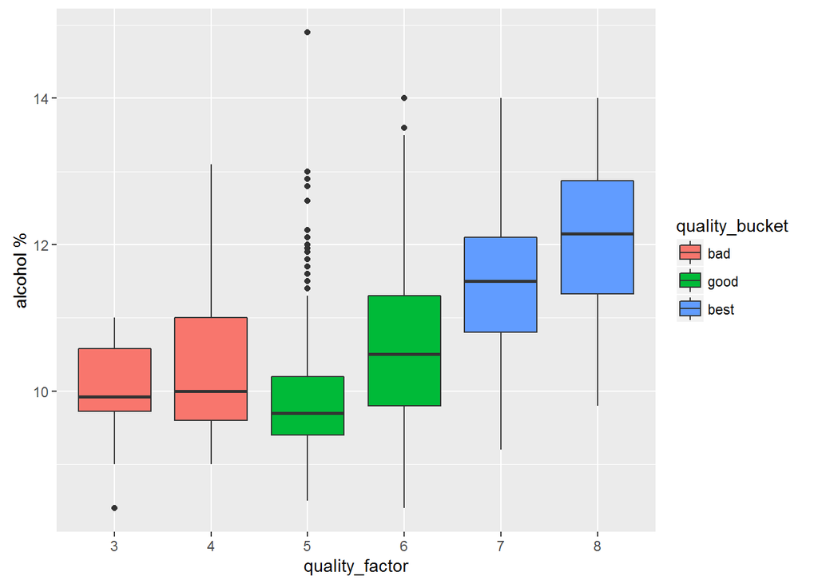

The alcohol% has a high positive correaltion with quality. A box plot with quality and alcohol% for different quality bucket will give a clear variation of alcohol% for each type of quality. The box plot show that alcohol % is one of the key ingredient in determinig the quality of the wine as the variations is very much seen as **higher** the *alcohol* contant the *quality* of the wine fall into `best` quality wine category.

## Plot two [relationship between *residual_suger* with *density*]

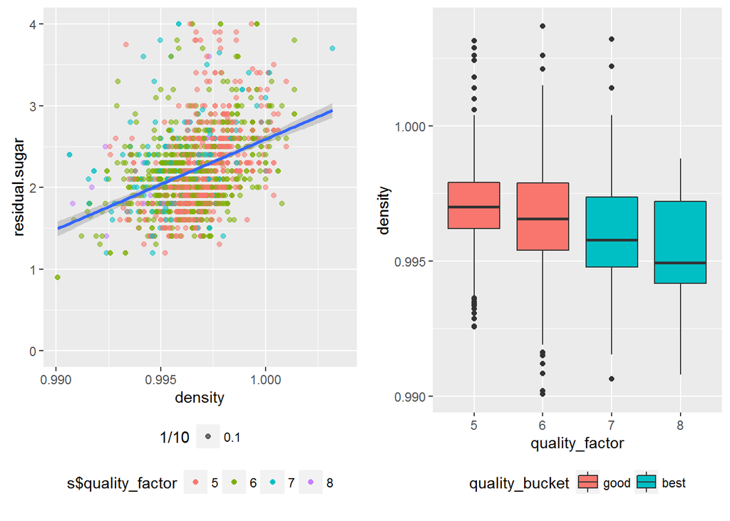

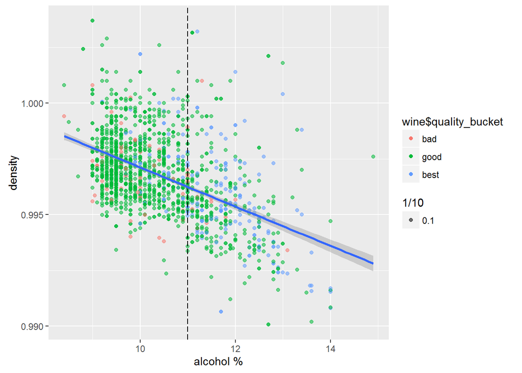

A scatter plot of Alcohol % vs density had a clear trend but adding quality as color helped to find the key properties of the `best` quality wine. There is a trend that most of the best quality wine are from the graph it is clear that the wine with more alcohol contant and less density falls in the `best` quality and the `good` quality wine has comparetively less alcohol contain and dinsity to best quality.

# Conclusion

From various plots i was able to summarise the property of the **best quality wine**. The following table contain the propreties *best quality wine*.

[output not shown]

# Reflection